# R3 — Cobertura y consumo de vehículos fortificables

ENGIH 2018, República Dominicana | Indicadores 1 y 2 del sistema de evaluación

Autor/a

Maicel E. Monzón

Fecha de publicación

12 de septiembre de 2026

> Todas las cifras se calculan al renderizar, directamente desde el pipeline. Ninguna está escrita a mano. Fecha de generación: 12-09-2026.

## 1 Qué responde este reporte

Los Términos de Referencia (numeral 4.2) piden estimar los dos primeros indicadores del sistema de evaluación: **cobertura** y **consumo** de los alimentos fortificables. Es también el primer punto de la especificación acordada con la contraparte técnica: *qué proporción de la población consume el vehículo fortificado*.

La pregunta que responde la cobertura es deliberadamente acotada: **¿el hogar consume arroz?** — no si ese arroz en particular estaba fortificado. Esa distinción hace que este reporte sea **independiente de la decisión pendiente sobre la línea base de fortificación**, y por eso sus cifras son estables.

## 2 Cobertura por vehículo

Un hogar cuenta como consumidor de un vehículo si registró al menos una adquisición o existencia de ese alimento durante el período de medición.

Tabla 1: Proporción de hogares que consumen cada vehículo de fortificación

[output not shown]

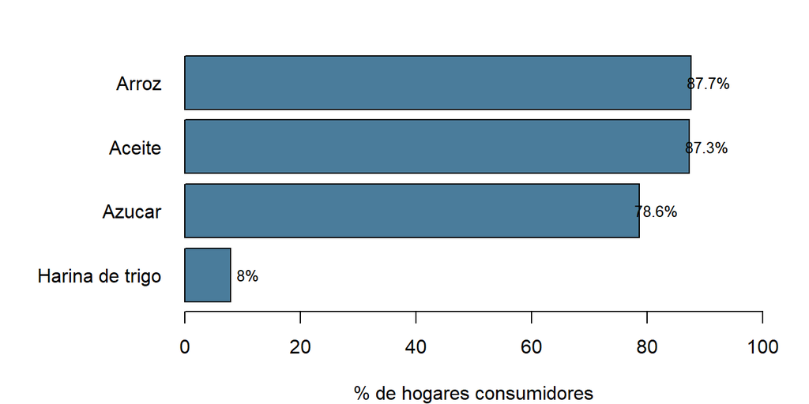

Figura 1: Cobertura de los vehículos de fortificación

La diferencia entre el porcentaje sin ponderar y el ponderado por el factor de expansión indica en qué medida el consumo del vehículo se concentra en hogares con distinta representatividad muestral. Una brecha amplia merece lectura cuidadosa; una brecha estrecha indica un consumo transversal a la población.

## 3 El caso de la harina de trigo

Tabla 2: Cobertura del vehículo trigo según cómo se defina el indicador

| Definición | Hogares | % de hogares |
| --- | --- | --- |
| Harina de trigo como producto | 700 | 8% |
| Harina de trigo y sus derivados | 7,521 | 85.7% |

La harina de trigo apenas aparece como producto comprado: en la Sección 2 no la registra **ningún** hogar. No es un vacío de los datos, es un hecho del patrón de consumo dominicano — la harina se consume ya procesada, principalmente en forma de pan.

Esto importa para la evaluación del programa. La normativa dominicana obliga a fortificar la harina **en el molino**, y esa harina llega al hogar dentro del pan. Un indicador construido sobre “harina de trigo” mide el consumo de un insumo intermedio, no la exposición de la población al nutriente añadido.

**Decisión adoptada:** el vehículo se define como *harina de trigo y sus derivados de consumo directo*, y se reportan ambas cifras para que la diferencia sea visible. Es una decisión de definición de indicador, y sus límites se declaran abajo.

Tabla 3: Alimentos incluidos en la definición ampliada, por volumen de registros

| Alimento | Filas |
| --- | --- |
| Pan sobado | 10,055 |
| Pan de agua | 6,221 |
| Galletas saladas | 3,283 |
| Fideos | 1,703 |
| GALLETAS SALADAS | 1,270 |
| Harina de trigo | 882 |
| Galletas dulces | 835 |
| Galletas de soda | 832 |
| GALLETAS DULCES | 413 |
| Galletas integrales | 217 |
| Bizcocho envasado de vainilla | 113 |
| Pan integral | 71 |
| Pan de sándwich rebanado blanco | 58 |
| Macarrones | 43 |
| Sopa con fideo (Maggie, Knorr y similares) | 41 |

**AdvertenciaDos limitaciones de la definición ampliada**

**No toda la harina contenida en estos productos está fortificada.** La norma es obligatoria para la harina de panificación, pero voluntaria para pastas y galletas. La cifra ampliada debe leerse como un **techo** del alcance real.

**No permite estimar gramos de harina consumidos.** Sin factores de receta —cuánta harina contiene cada producto— la definición ampliada es válida como medida de **alcance poblacional**, pero no para calcular el aporte en gramos. Esos factores no están disponibles en esta encuesta y su incorporación queda identificada como línea de trabajo.

## 4 Consumo entre quienes consumen

La cobertura por sí sola no basta para evaluar una estrategia de fortificación: un vehículo consumido por todos pero en cantidades mínimas aporta poco. Esta sección reporta cuánto consume quien consume.

Tabla 4: Consumo diario por EMA entre hogares consumidores (gramos)

| Vehiculo | Hogares | Mediana | Media | P25 | P75 | P95 |
| --- | --- | --- | --- | --- | --- | --- |
| Arroz | 7,693 | 207.8 | 274.9 | 132.4 | 312.9 | 723.4 |
| Azucar | 6,900 | 48.0 | 74.1 | 26.1 | 86.3 | 218.5 |
| Aceite | 7,662 | 41.9 | 74.5 | 19.2 | 85.1 | 244.0 |
| Harina de trigo | 700 | 31.9 | 56.3 | 18.3 | 54.9 | 159.4 |

**NotaPor qué la mediana y no la media**

En todos los vehículos la media supera a la mediana, señal de una distribución sesgada a la derecha por compras al por mayor: un hogar que adquiere un saco de arroz en un solo día del período registra un consumo diario aparente muy alto. **La mediana es el estimador central que se reporta**; la media se muestra al lado para que la diferencia quede visible en lugar de oculta.

## 5 Consumo simultáneo de vehículos

Una estrategia de fortificación puede apoyarse en un vehículo único o en un conjunto. Saber cuántos hogares quedarían alcanzados por al menos uno es directamente relevante para el diseño.

Tabla 5: Número de vehículos distintos consumidos por hogar

[output not shown]

**Al menos un vehículo:** 8,279 hogares (94.4% del total analizado).

**Los cuatro vehículos a la vez:** 577 hogares (6.6%).

## 6 Aporte por sección del cuestionario

La ENGIH captura el consumo por dos vías distintas: la Sección 2 releva las existencias del hogar y la Sección 3A las adquisiciones diarias. **No son intercambiables ni redundantes**: capturan alimentos distintos y el análisis requiere ambas. Esta tabla muestra de dónde proviene la cobertura de cada vehículo.

Tabla 6: Hogares consumidores según la sección que registró el consumo

| Vehiculo | Sec 2 | Sec 3A |
| --- | --- | --- |
| Aceite | 4,988 | 3,827 |
| Arroz | 4,595 | 4,539 |
| Azucar | 4,186 | 4,211 |
| Harina de trigo | 0 | 700 |

**ImportanteSolapamiento en alimentos almacenables**

Un mismo hogar puede aparecer en ambas secciones para el mismo vehículo: tenía arroz almacenado **y** compró arroz durante el período. Para los vehículos —todos ellos almacenables— esto implica que **el consumo agregado está sobrestimado** en una magnitud aún no cuantificada por alimento.

El refinamiento metodológico apropiado es la **disponibilidad neta** (existencias iniciales + adquisiciones − existencias finales), para la cual los datos necesarios ya están disponibles en la Sección 2. Queda documentado como trabajo pendiente; **la cobertura, al ser una medida binaria de consumo sí/no, no se ve afectada por este solapamiento** — solo el consumo en gramos.

## 7 Limitaciones

- **Cobertura del pipeline.** Las cifras se calculan sobre las observaciones que completan la cadena de cálculo (cantidad, factor de conversión y porción comestible). Ver el reporte R1 para el detalle por sección.
- **Sin intervalos de confianza.** La ENGIH tiene diseño muestral complejo (8 estratos, 933 unidades primarias, factor de expansión). Las variables están disponibles y su incorporación mediante `srvyr` es el siguiente paso; **hasta entonces no se reportan intervalos**, en lugar de reportar intervalos incorrectamente estrechos.
- **El consumo en gramos está sobrestimado** por el solapamiento entre secciones descrito arriba. La cobertura no lo está.
- **Definición de los vehículos.** Se identifican por patrón de texto sobre la descripción de la ENGIH, definido en un único lugar (`_comun.R`) y por tanto auditable y modificable sin tocar este reporte.

## 8 Lectura para la toma de decisiones

Un vehículo con cobertura alta y consumo mediano estable es candidato preferente para una estrategia de fortificación, porque alcanza a la población de forma transversal. Uno con cobertura baja requiere combinarse con otros para lograr alcance poblacional suficiente.

La estimación del **aporte efectivo de cada vehículo a la ingesta de micronutrientes** —indicadores 3 y 4 del sistema de evaluación— depende de la definición de la línea base de fortificación, que es una decisión de política pendiente y se documenta por separado.

*Generado desde el pipeline reproducible del proyecto: `scripts/01_import.R` → `scripts/04_equivalente_adulto.R`.*